# SVM Tutorial NHANES

Hayden Deverill

2024-12-05

# Introduction

In this tutorial, we will use **Support Vector Machines (SVM)** to predict extreme blood pressure (a binary outcome) using data from the **NHANES dataset**. The workflow includes:

1. Loading necessary packages and data.
2. Preprocessing and cleaning the data.
3. Feature selection for identifying important predictors.
4. Training and evaluating an SVM classifier.
5. Visualizing the SVM decision boundary.

# Load Required Packages

We start by loading the necessary R packages. Each package is labeled with its purpose to maintain clarity.

```r
# Load necessary packages
library(randomForest)   # Feature selection
library(e1071)          # SVM model
library(tidyverse)      # Data manipulation
library(caret)          # Data splitting and feature selection
```

# Load the Data

We load the **NHANES Nutrition Data** and perform a quick inspection of its structure and contents.

```r
# Load and inspect the data
data <- read_csv("C:/Users/hayden.deverill/OneDrive - West Point/Sarah Booth Paper/Data/NHANES Data/Nutrition Data from NHANES.csv")
```

```
## ──────────────────────────────────────────────────────── Delimiter: "," chr
## (1): gender dbl (20): ...1, SEQN, age, bp_sys, bp_di, weight, height, bmi,
## waist, kcal, ... lgl (8): med_hbp, med_chol, extreme_bp, extreme_waist,
## extreme_hdl, extreme...
```

```r
# Display the first few rows of the data
head(data)
```

```
## # A tibble: 6 × 29
##    ...1  SEQN   age bp_sys bp_di weight height   bmi waist  kcal protein sugar
##   <dbl> <dbl> <dbl>  <dbl> <dbl>  <dbl>  <dbl> <dbl> <dbl> <dbl>   <dbl> <dbl>
## 1     1 93711    56    108    68   62.1   171.  21.3  86.6  2840   101.  148.
## 2     2 93717    22    116    62   74.4   174.  24.5  86.2  3151    97.1 137.
## 3     3 93719    13    102    62   67     160.  26    86    2224    80.5 163.
## 4     4 93721    60    132    68   85.1   154   35.9 113.   1930    80.0 105.
## 5     5 93722    60    116    68   56.8   155.  23.8  89.7  1009    22.7  87.6
## 6     6 93731    20    114    54   89.2   180.  27.6 102.   2266    71.8 126.
## # ℹ 17 more variables: carb <dbl>, fat_total <dbl>, fat_sat <dbl>,
## #   fat_mon <dbl>, fat_poly <dbl>, hdl <dbl>, glucose <dbl>,
## #   triglycerides <dbl>, gender <chr>, med_hbp <lgl>, med_chol <lgl>,
## #   extreme_bp <lgl>, extreme_waist <lgl>, extreme_hdl <lgl>,
## #   extreme_tri <lgl>, extreme_glu <lgl>, metsyn <lgl>
```

# Data Preprocessing

## Convert Categorical Variables to Factors

```r
# Convert categorical variables to factors
data$med_hbp <- as.factor(data$med_hbp)
data$med_chol <- as.factor(data$med_chol)
data$extreme_bp <- as.factor(data$extreme_bp)
data$extreme_waist <- as.factor(data$extreme_waist)
data$extreme_hdl <- as.factor(data$extreme_hdl)
data$extreme_tri <- as.factor(data$extreme_tri)
data$extreme_glu <- as.factor(data$extreme_glu)
data$metsyn <- as.factor(data$metsyn)
```

## Clean and Prepare the Dataset

```r
# Rename 'gender' to 'sex' and convert it to a factor
data$sex <- as.factor(data$gender)

# Remove 'gender' column
data <- data %>% select(-gender)

# Remove rows with missing values
data <- na.omit(data)

# Display a summary of selected features
summary(data[, c("age", "bmi", "sex", "carb", "fat_total", "protein", "extreme_bp")])
```

```
##       age             bmi            sex           carb
##  Min.   :28.00   Min.   :18.40   female:178   Min.   :  22.33
##  1st Qu.:57.75   1st Qu.:26.77   male  :182   1st Qu.: 150.32
##  Median :64.00   Median :29.90                Median : 210.91
##  Mean   :64.06   Mean   :31.17                Mean   : 230.61
##  3rd Qu.:72.00   3rd Qu.:34.40                3rd Qu.: 294.35
##  Max.   :80.00   Max.   :61.60                Max.   :1134.08
##    fat_total         protein       extreme_bp
##  Min.   :  1.97   Min.   :  2.89   FALSE:158
##  1st Qu.: 50.60   1st Qu.: 50.04   TRUE :202
##  Median : 75.93   Median : 69.85
##  Mean   : 80.76   Mean   : 76.26
##  3rd Qu.:102.58   3rd Qu.: 96.67
##  Max.   :268.28   Max.   :213.09
```

# Splitting the Data into Training and Testing Sets

We split the data into **80% training** and **20% testing**.

```r
# Split the data
set.seed(123) # for reproducibility
trainIndex <- createDataPartition(data$bp_sys, p = 0.8, list = FALSE)
train_data <- data[trainIndex, ]
test_data <- data[-trainIndex, ]
```

# Standardize the Data

Standardization is crucial for SVM because it relies on distance-based optimization. We calculate the mean and standard deviation from the training data and scale both the training and test datasets accordingly.

```r
# Identify numeric and non-numeric features
numeric_features <- train_data[sapply(train_data, is.numeric)] %>% colnames()
non_numeric_features <- train_data[sapply(train_data, is.factor)] %>% colnames()

# Compute mean and SD of numeric features in the training set
train_mean <- colMeans(train_data[numeric_features])
train_sd <- apply(train_data[numeric_features], 2, sd)

# Scale the training and test datasets
train_scaled <- scale(train_data[numeric_features], center = train_mean, scale = train_sd)
test_scaled <- scale(test_data[numeric_features], center = train_mean, scale = train_sd)

# Combine scaled numeric and non-numeric columns
train_data_scaled <- cbind(train_scaled, train_data[non_numeric_features])
test_data_scaled <- cbind(test_scaled, test_data[non_numeric_features])
```

The final output are the `train_data_scaled` and `test_data_scaled` data sets that are preprocessed to use with the SVM model.

# Feature Selection

## Using Random Forest to Identify Important Features

Random forest is an ensemble method that builds multiple decision trees during training. Each tree is built using a random subset of predictors (a process called feature bagging), which helps reduce overfitting and increases model robustness.

The random forest’s internal mechanism calculates variable importance based on how much each feature contributes to reducing impurity (e.g., Gini index for classification or residual sum of squares for regression).

```r
# Train a random forest model for feature selection
set.seed(7)
control <- trainControl(method = "repeatedcv", number = 10, repeats = 3)
model <- train(extreme_bp ~ .,
               data = data %>% select(-c(bp_sys, bp_di)), #bp_sys and bp_di are correlated to extreme_bp
               method = "rf",
               preProcess = c("center", "scale"),
               trControl = control)

# Display the model and variable importance
print(model)
```

```
## Random Forest
##
## 360 samples
##  26 predictor
##   2 classes: 'FALSE', 'TRUE'
##
## Pre-processing: centered (26), scaled (26)
## Resampling: Cross-Validated (10 fold, repeated 3 times)
## Summary of sample sizes: 323, 324, 324, 324, 323, 324, ...
## Resampling results across tuning parameters:
##
##   mtry  Accuracy   Kappa
##    2    0.6771650  0.3257772
##   14    0.6975161  0.3804585
##   26    0.6781203  0.3429859
##
## Accuracy was used to select the optimal model using the largest value.
## The final value used for the model was mtry = 14.
```

```r
importance <- varImp(model, scale = FALSE)
print(importance)
```

```
## rf variable importance
##
##   only 20 most important variables shown (out of 26)
##
##                 Overall
## metsynTRUE       17.997
## height           14.450
## weight           12.014
## triglycerides    10.616
## protein           9.972
## age               9.231
## waist             9.030
## glucose           8.408
## bmi               8.226
## hdl               7.883
## fat_sat           7.287
## fat_total         7.204
## fat_mon           6.883
## ...1              6.560
## SEQN              6.179
## carb              6.043
## sugar             6.019
## fat_poly          5.970
## kcal              5.917
## extreme_hdlTRUE   5.386
```

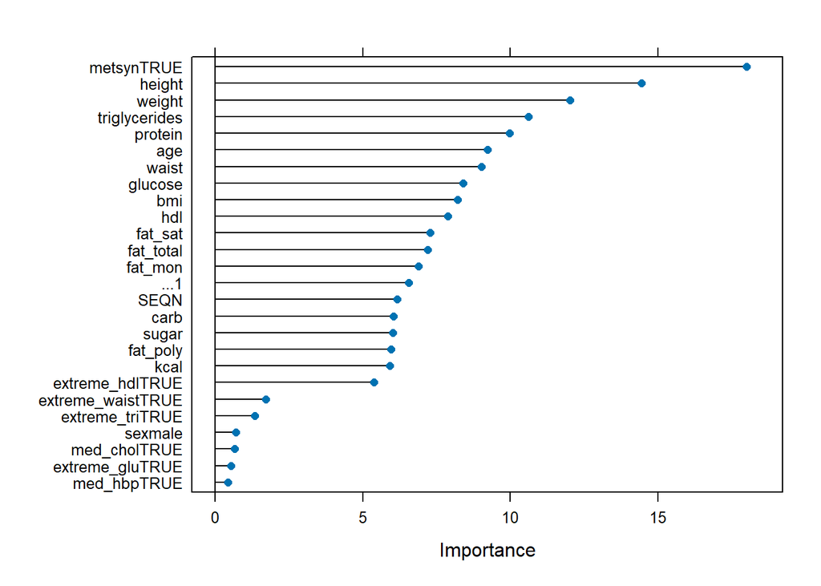

```r
plot(importance)
```

Using the **random forest** feature selection method, the five most important features are:

1. metsynTRUE
2. height
3. weight
4. triglycerides
5. protein

## Recursive Feature Elimination (RFE)

Recursive Feature Elimination (RFE) method is a systematic approach to feature selection. It iteratively trains models while removing less important features based on some criterion, identifying the subset of predictors that leads to the best model performance.

```r
# Recursive Feature Elimination (RFE)
set.seed(7)
control <- rfeControl(functions = rfFuncs, method = "cv", number = 10)
results <- rfe(data[, c(1:3, 6:22, 24:29)], data$extreme_bp, sizes = c(1:8), rfeControl = control)

# Display chosen features
print(results)
```

```
##
## Recursive feature selection
##
## Outer resampling method: Cross-Validated (10 fold)
##
## Resampling performance over subset size:
##
##  Variables Accuracy  Kappa AccuracySD KappaSD Selected
##          1   0.6638 0.3079    0.06407 0.13576
##          2   0.6499 0.2819    0.07011 0.14675
##          3   0.6556 0.2795    0.05997 0.12936
##          4   0.6498 0.2888    0.07283 0.15116
##          5   0.6475 0.2845    0.06534 0.13425
##          6   0.6695 0.3273    0.04941 0.09933
##          7   0.6613 0.3099    0.05377 0.11214
##          8   0.6723 0.3327    0.06334 0.12745
##         26   0.6860 0.3521    0.07689 0.15879        *
##
## The top 5 variables (out of 26):
##    metsyn, height, weight, fat_mon, hdl
```

```r
predictors(results)
```

```
##  [1] "metsyn"        "height"        "weight"        "fat_mon"
##  [5] "hdl"           "waist"         "extreme_hdl"   "fat_sat"
##  [9] "bmi"           "fat_total"     "triglycerides" "age"
## [13] "protein"       "extreme_tri"   "kcal"          "SEQN"
## [17] "extreme_waist" "sex"           "carb"          "...1"
## [21] "sugar"         "fat_poly"      "extreme_glu"   "glucose"
## [25] "med_hbp"       "med_chol"
```

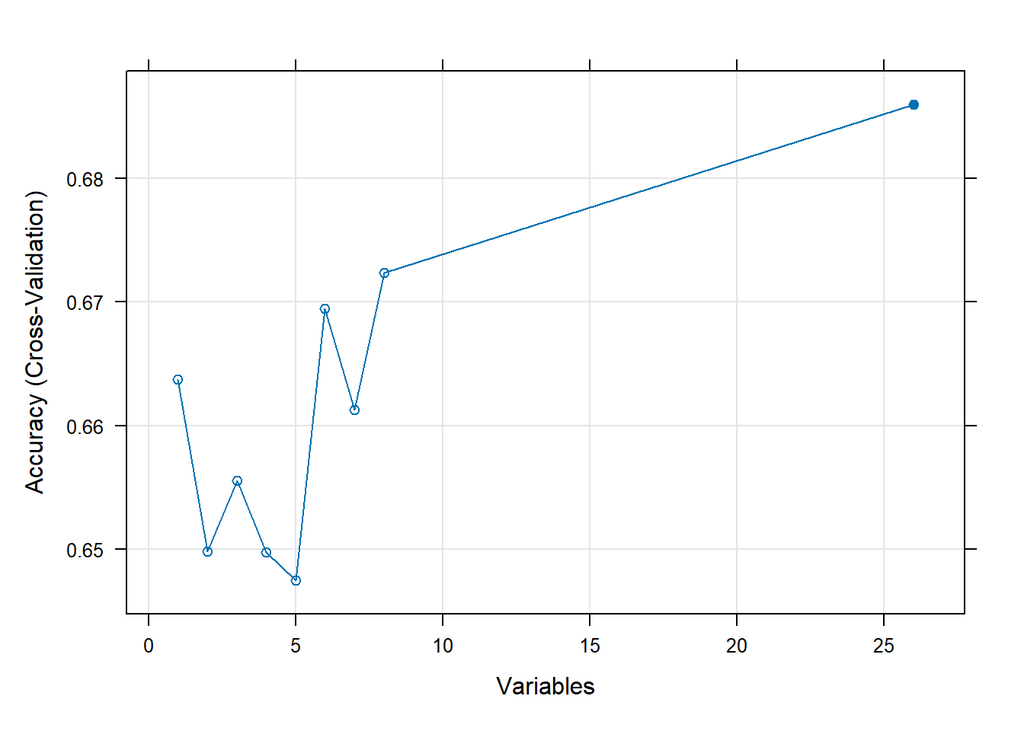

```r
plot(results, type = c("g", "o"))
```

Using the **RFE** feature selection method, the five most important features are:

1. metsynTRUE
2. height
3. weight
4. fat_mon
5. hdl

Overall, we see that both methods had metsynTRUE, height, and weight as the top three most important features. However, the fourth and fifth most important features for each respective method were different.

# Train the SVM Classifier

We use the SVM model with a **linear kernel** and specific input variables to predict extreme blood pressure.

We chose to fit the model using the following variables based on both the feature importance and subject matter expert opinion:

1. height
2. weight
3. triglycerides
4. waist
5. protein
6. age
7. glucose

```r
# Train the SVM model
set.seed(123)
svm_model <- svm(extreme_bp ~ height + weight + triglycerides + waist + protein + age + glucose,
                 data = train_data_scaled,
                 kernel = "linear",
                 scale = TRUE,
                 cost = 10)

# Print model summary
print(svm_model)
```

```
##
## Call:
## svm(formula = extreme_bp ~ height + weight + triglycerides + waist +
##     protein + age + glucose, data = train_data_scaled, kernel = "linear",
##     cost = 10, scale = TRUE)
##
##
## Parameters:
##    SVM-Type:  C-classification
##  SVM-Kernel:  linear
##        cost:  10
##
## Number of Support Vectors:  251
```

# Evaluate the Model

Finally, we test the model on unseen data and calculate performance metrics.

```r
# Predict on test data
test_predictions <- predict(svm_model, test_data_scaled)

# Generate a confusion matrix
confusion <- confusionMatrix(test_predictions, test_data_scaled$extreme_bp, positive = "TRUE")

# Print confusion matrix
print(confusion)
```

```
## Confusion Matrix and Statistics
##
##           Reference
## Prediction FALSE TRUE
##      FALSE    14    8
##      TRUE     18   30
##
##                Accuracy : 0.6286
##                  95% CI : (0.5048, 0.7411)
##     No Information Rate : 0.5429
##     P-Value [Acc > NIR] : 0.09285
##
##                   Kappa : 0.2327
##
##  Mcnemar's Test P-Value : 0.07756
##
##             Sensitivity : 0.7895
##             Specificity : 0.4375
##          Pos Pred Value : 0.6250
##          Neg Pred Value : 0.6364
##              Prevalence : 0.5429
##          Detection Rate : 0.4286
##    Detection Prevalence : 0.6857
##       Balanced Accuracy : 0.6135
##
##        'Positive' Class : TRUE
##
```

We see that the accuracy is **62.86%** as a result of using this model.

# Visualize SVM Decision Boundary

## Train the SVM Classifier (Height and Weight Only)

We use the SVM model with a **linear kernel** using height and weight to predict extreme blood pressure to effectively visualize the decision boundary on a 2 dimensional space.

```r
# Train the SVM model
svm_model2 <- svm(extreme_bp ~ height + weight,
                 data = train_data_scaled,
                 kernel = "linear",
                 scale = TRUE,
                 cost = 10)

# Print model summary
print(svm_model2)
```

```
##
## Call:
## svm(formula = extreme_bp ~ height + weight, data = train_data_scaled,
##     kernel = "linear", cost = 10, scale = TRUE)
##
##
## Parameters:
##    SVM-Type:  C-classification
##  SVM-Kernel:  linear
##        cost:  10
##
## Number of Support Vectors:  250
```

## Evaluate the Model

Finally, we test the model on unseen data and calculate performance metrics.

```r
# Predict on test data
predictions2 <- predict(svm_model2, test_data_scaled)

# Generate a confusion matrix
confusion2 <- confusionMatrix(predictions2, test_data_scaled$extreme_bp, positive="TRUE")

# Print confusion matrix
print(confusion2)
```

```
## Confusion Matrix and Statistics
##
##           Reference
## Prediction FALSE TRUE
##      FALSE    15    9
##      TRUE     17   29
##
##                Accuracy : 0.6286
##                  95% CI : (0.5048, 0.7411)
##     No Information Rate : 0.5429
##     P-Value [Acc > NIR] : 0.09285
##
##                   Kappa : 0.2366
##
##  Mcnemar's Test P-Value : 0.16981
##
##             Sensitivity : 0.7632
##             Specificity : 0.4688
##          Pos Pred Value : 0.6304
##          Neg Pred Value : 0.6250
##              Prevalence : 0.5429
##          Detection Rate : 0.4143
##    Detection Prevalence : 0.6571
##       Balanced Accuracy : 0.6160
##
##        'Positive' Class : TRUE
##
```

## Plot the Decision Boundary (Base R Plot)

### Define the Feature Space Grid

We first define a grid over the feature space to compute decision values for plotting the decision boundary.

```r
# Define a grid over the feature space for plotting
x_seq <- seq(min(train_data_scaled$height), max(train_data_scaled$height), length = 300)
y_seq <- seq(min(train_data_scaled$weight), max(train_data_scaled$weight), length = 300)
grid <- expand.grid(height = x_seq, weight = y_seq)
```

### Compute Decision Values

Using the grid, we predict decision values with the trained SVM model.

```r
# Get decision values for the grid
decision_values <- predict(svm_model2, grid, decision.values = TRUE)
decision <- attr(decision_values, "decision.values")
```

### Plot the Data Points and Decision Boundary

Here, we plot the training data points, support vectors, decision boundary, and margins.

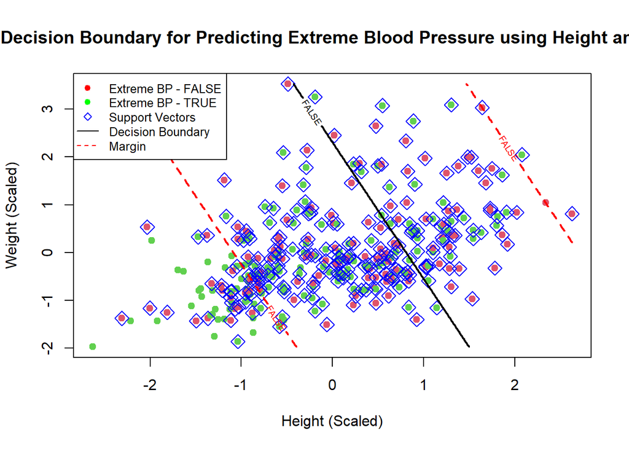

```r
# Plot data points
plot(train_data_scaled$height, train_data_scaled$weight,
     col = as.integer(train_data_scaled$extreme_bp) + 1,
     pch = 19, xlab = "Height (Scaled)", ylab = "Weight (Scaled)")

# Highlight support vectors
points(svm_model$SV, col = "blue", pch = 5, cex = 1.5)

# Plot decision boundary and margins
contour(x_seq, y_seq, matrix(decision, 300, 300), levels = c(-1, 0, 1),
        label = FALSE, add = TRUE, col = c("red", "black", "red"),
        lwd = 2, lty = c(2, 1, 2))

# Add legend
legend("topleft",
       legend = c("Extreme BP - FALSE", "Extreme BP - TRUE",
                  "Support Vectors", "Decision Boundary", "Margin"),
       col = c("red", "green", "blue", "black", "red"),
       pch = c(19, 19, 5, NA, NA), lty = c(NA, NA, NA, 1, 2), cex = 0.8)

# Add title
title("SVM Decision Boundary for Predicting Extreme Blood Pressure using Height and Weight")
```